# The Infer Package and Bayes Factors

Jon Minton

# Introduction

This document will introduce a couple of concepts, and one R package, for performing statistical inference tests in R.

1. The There-is-only-one-test framework, and the R package infer
2. Bayes Factors, as distinct from Neyman-Pearson Hypothesis Testing frameworks

# Proposed structure

- TIOOT/Infer
  - There-is-only-one-test : background
    - Allen Downey - a computer scientist’s take on statistical inference
      - 2011 - [There is only one test](http://allendowney.blogspot.com/2011/05/there-is-only-one-test.html)
      - 2016 - [There is still only one test](http://allendowney.blogspot.com/2016/06/there-is-still-only-one-test.html)

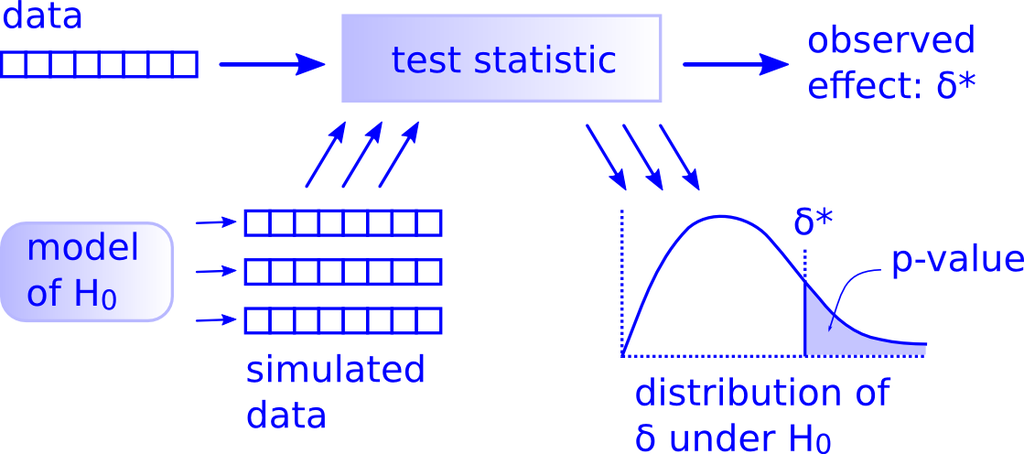

    - Null & Alternative Hypothesis
      - Null $H_0$: The (boring) world in which the proposed relationship between predictor and response variables is *false*
      - Alternative $H_A$: The (interesting) world in which the proposed relationship between predictor and response is *true*
    - P-values
      - > P-values are a measure of conflict between data and a hypothesis, and are certainly not direct expressions of a probability of hypotheses.
        - [Communicating Uncertainty about facts, numbers, and science](https://royalsocietypublishing.org/doi/pdf/10.1098/rsos.181870)
      - P-values are usually *indirect* strategies for investigating support for $H_A$, through quantifying *magnitude* and *direction* of conflict between data and $H_0$
        - *Direction of conflict*: One-tailed cf two-tailed tests
        - *Magnitude of conflict*: Probability of observing values of effect $\delta^{*}$ as or more extreme under $H_0$.
      - Neyman-Pearson Approach
        - Also prespecify $\alpha$: The magnitude of conflict between data and Null hypothesis, in expected direction, required to ‘reject the Null’
        - Typical $\alpha$ values: 0.05, 0.01
          - CERN: ‘Five Sigma’ (almost zero)
        - [The Sizeless Stare](https://www.amazon.co.uk/Cult-Statistical-Significance-Economics-Cognition/dp/0472050079)
      - Permutation approaches
        - A generic, computationally intensive, approach to producing a distribution of expected effect sizes under the Null
        - Key intuition:
          - $H_A$ says $X$ predicts/causes $Y$
          - Put another way: Values of $X$ are *informative* as to values of $Y$
          - Say $X$ is categorical, and can either be $A$ or $B$
          - The data $D$ is a series of values of $Y$, with *labels* attached: the corresponding values of $X$
          - Another way of expressing $H_A$ and $H_0$:
            - $H_A$: These labels *matter* (Are informative of $Y$)
            - $H_0$: These labels *don’t matter* (Are not informative of $Y$)
          - A corollary of $H_0$: If the labels don’t matter, there’s no harm (information lost) by reallocating them to $Y$ values at random
          - Random reallocation: Permutation
          - Repeat many times to estimate the Null distribution
  - [Infer package](https://github.com/tidymodels/infer)

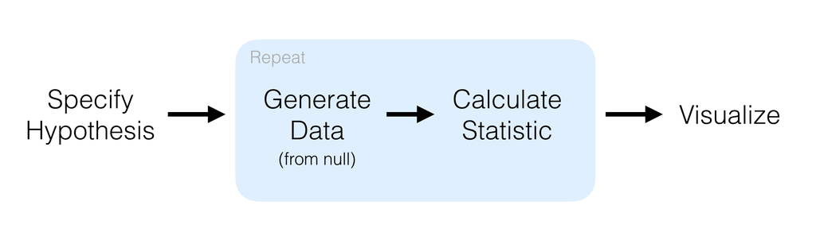

    - Verbs
      - `specify`
      - `hypothesize`
      - `generate`
      - `calculate`
  - DataCamp courses [(Learner beware)](https://www.buzzfeednews.com/article/daveyalba/datacamp-sexual-harassment-metoo-tech-startup)
    - [Foundations of Inference](https://www.datacamp.com/courses/foundations-of-inference)
    - [Inference for Linear Regression](https://www.datacamp.com/courses/inference-for-linear-regression)
    - [Inference for Numeric Data](https://www.datacamp.com/courses/inference-for-numerical-data)
    - [Inference for Categorical Data](https://www.datacamp.com/courses/inference-for-categorical-data)
  - [Avoiding Datacamp](https://bookdown.org/cteplovs/ismaykim/ismaykim.pdf)

# Examples of infer

```r
pacman::p_load(tidyverse, infer)
```

# Initial example: mtcars

- [mtcars dataset](https://stat.ethz.ch/R-manual/R-devel/library/datasets/html/mtcars.html)

## Variables of interest

- **vs**: Engine (0 - V-shaped; 1 = straight)
- **am**: Transmission (0 = automatic, 1 = manual)
- **mpg**: Miles per gallon

## Prep the data

```r
mtcars <- as.data.frame(mtcars) %>%
  mutate(cyl = factor(cyl), # Number of cylinders
          vs = factor(vs), # is engine v-shaped?
          am = factor(am), # is transmission manual?
          gear = factor(gear),
          carb = factor(carb))
```

## First research question

```r
# Observed difference in proportions
obs_diff_rq1 <-
  mtcars %>%
    select(am, vs) %>%
    group_by(vs) %>%
    summarise(prop = mean(am == 1)) %>%
    summarise(diff_in_props = diff(prop)) %>%
    pull(diff_in_props)

obs_diff_rq1
```

```
## [1] 0.1666667
```

So, around 17% more manual-transmission cars have v-shaped engines than automatic transmission cars.

If there were no true relationship, what range of differences in proportions should we expect?

```r
# Null distribution:
null_rq1 <-
  mtcars %>%
    specify(am ~ vs, success = "1") %>%
    hypothesize(null = "independence") %>%
    generate(reps = 1000, type = "permute") %>%
    calculate(stat = "diff in props", order = c("1", "0"))

quantile(pull(null_rq1, stat), c(0.025, 0.5, 0.975))
```

```
##        2.5%         50%       97.5%
## -0.34126984  0.03968254  0.29365079
```

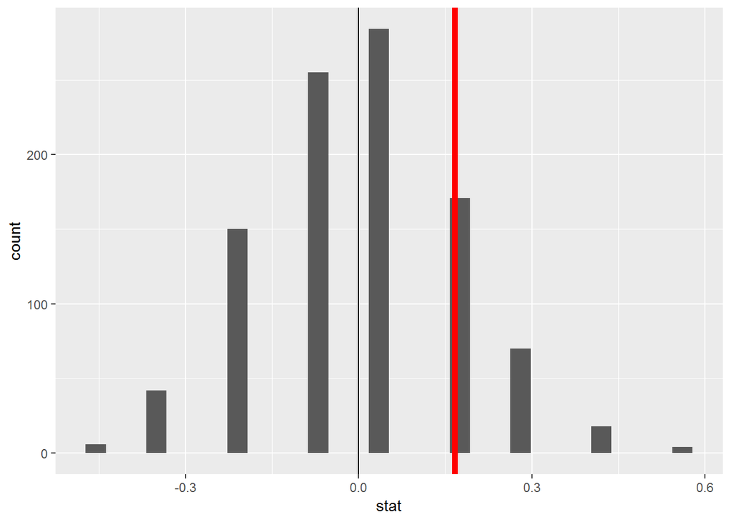

```r
# Visualise the Null

null_rq1 %>%
  ggplot(aes(x = stat)) +
  geom_histogram() +
  geom_vline(xintercept = 0) +
  geom_vline(xintercept = obs_diff_rq1, colour = "red", size = 2)
```

```r
# P-value (two sided)

null_rq1 %>%
  summarise(p_val = mean(abs(stat) > obs_diff_rq1))
```

| p_val |
| --- |
| 0.29 |

The null distribution generates differences of greater magnitude than the observed value nearly a third of the time.

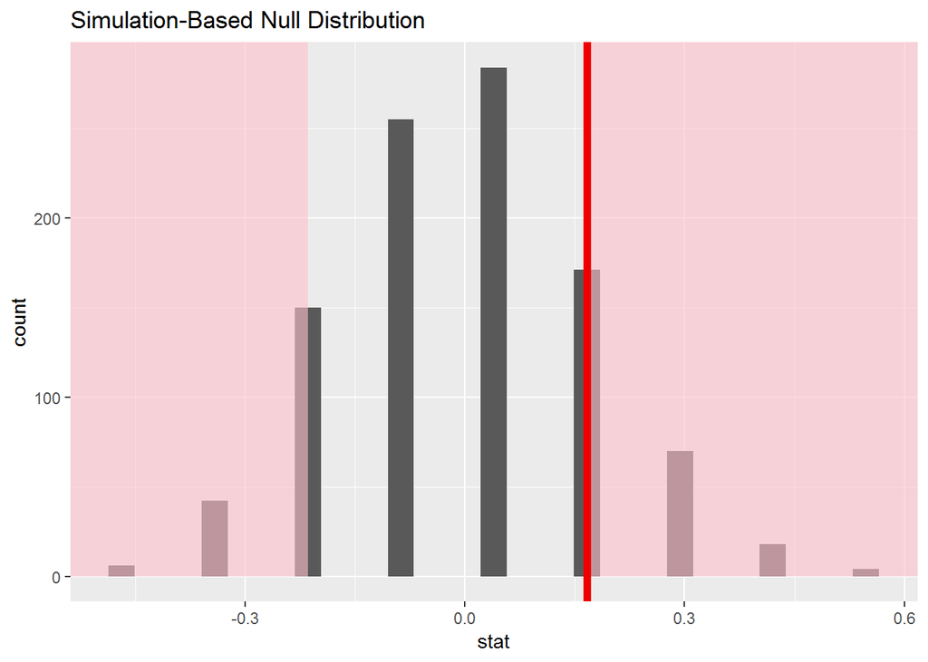

```r
null_rq1 %>%
  visualize() +
  shade_p_value(obs_diff_rq1, direction = "both")
```

## Second research question

> Do manual transmission vehicles (from the 1970s) have higher MPG?
- $H_A$: They do
- $H_0$: They don’t

```r
# Observed difference in means
obs_diff_rq2 <-
  mtcars %>%
    group_by(am) %>%
    summarise(mean_mpg = mean(mpg)) %>%
    summarise(diff_in_means = diff(mean_mpg)) %>%
    pull(diff_in_means)

obs_diff_rq2
```

```
## [1] 7.244939
```

```r
null_rq2 <-
  mtcars %>%
    specify(response = mpg, explanatory = am) %>%
    hypothesize(null = "independence") %>%
    generate(reps = 1000, type = "permute") %>%
    calculate(stat = "diff in means", order = c("1", "0"))
```

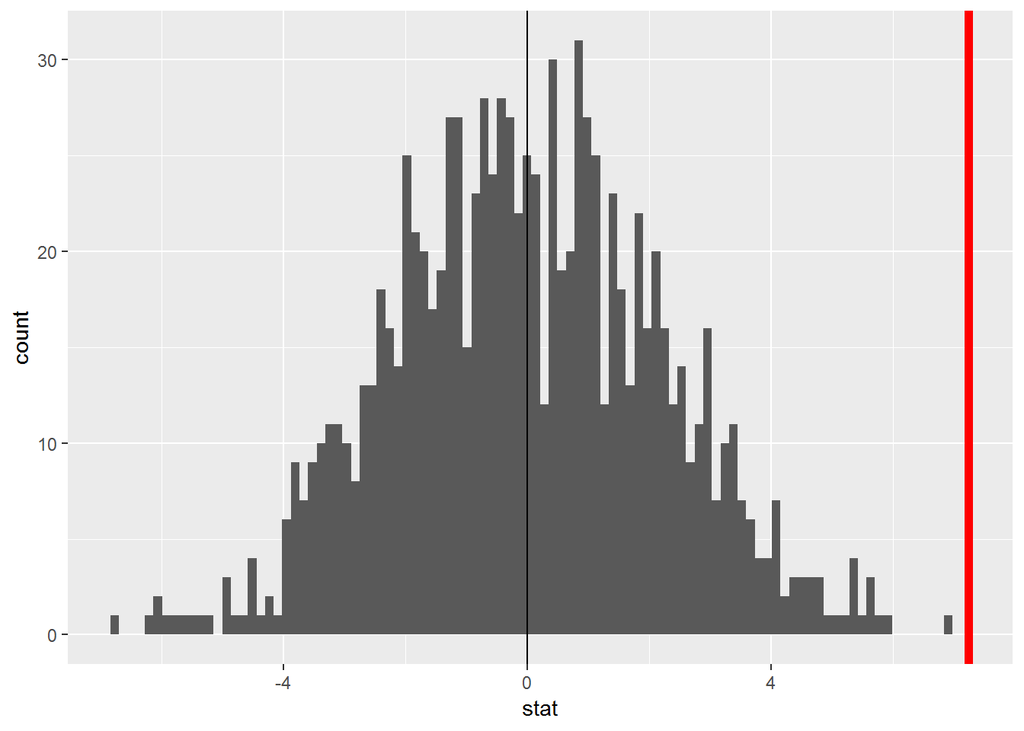

```r
# Visualise

null_rq2 %>%
  ggplot(aes(x = stat)) +
  geom_histogram(bins = 100) +
  geom_vline(xintercept = 0) +
  geom_vline(xintercept = obs_diff_rq2, colour = "red", size = 2)
```

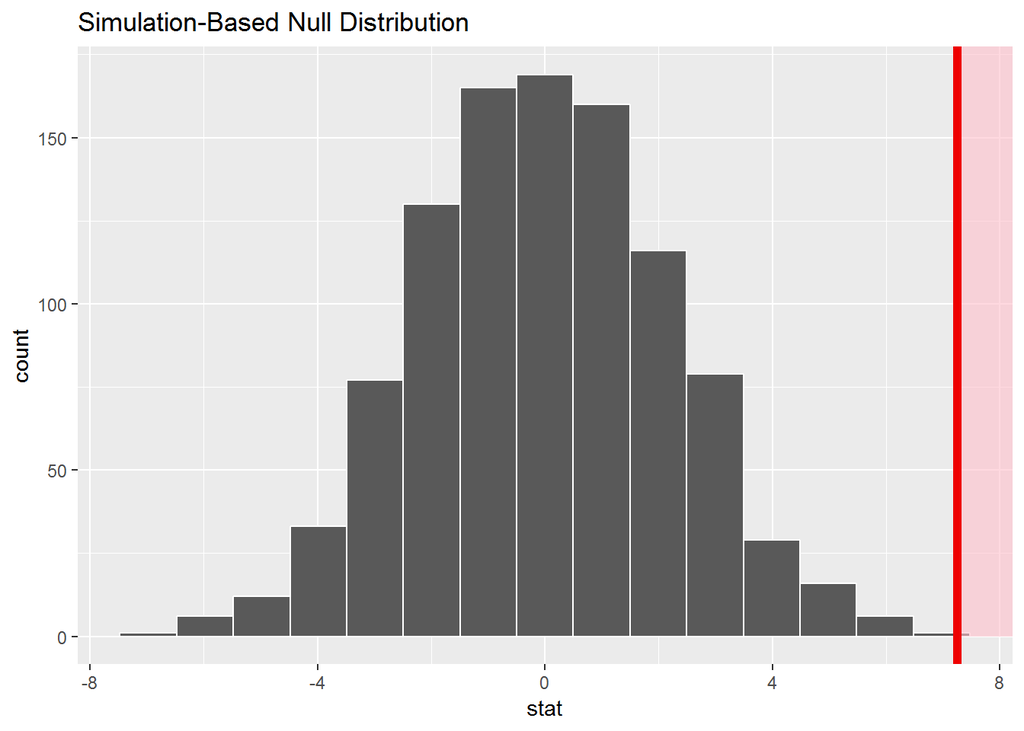

```r
# Visualise

null_rq2 %>%
  visualize() +
  shade_p_value(obs_diff_rq2, direction = "greater")
```

```r
# P-value (one-sided)

null_rq2 %>%
  summarise(p_val = mean(stat > obs_diff_rq2))
```

| p_val |
| --- |
| 0 |

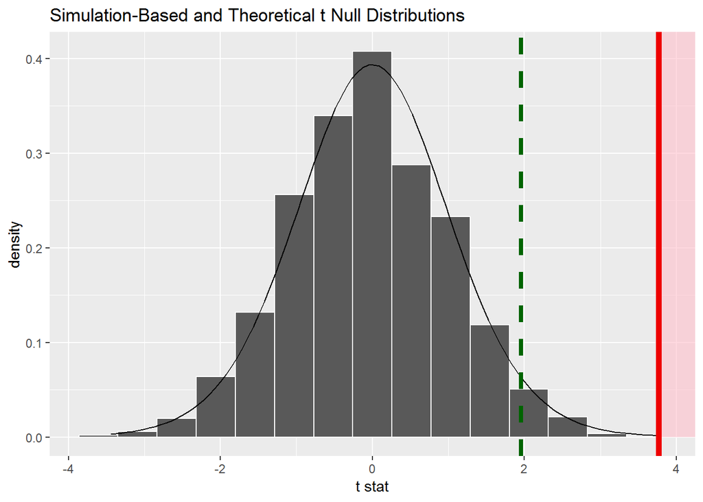

```r
# RQ2 using the t-distribution

obs_diff_rq2_t <-
  mtcars %>%
  t_test(mpg ~ am, order = c("1", "0"), alternative = "less")

mtcars %>%
  specify(response = mpg, explanatory = am) %>%
  hypothesize(null = "independence") %>%
  generate(reps = 1000, type = "permute") %>%
  calculate(stat = "t", order = c("1", "0")) %>%
  visualize(method = "both") +
  shade_p_value(obs_stat = obs_diff_rq2_t, direction = "greater") +
  geom_vline(xintercept = 1.96, colour = "darkgreen", size = 1.5, linetype = "dashed")
```

## Conclusion

Using two summary statistics (mean difference and t statistic), and for the statistic both permutation and analytic approaches, we conclude the same: there’s a statistically significant difference between the average MPG of manual and automatic transmission engines. (In cars from the 1970s)

# Second Example (If we get time)

> RQ: Are males taller than females (on average)
- $H_0$: No!
- $H_A$: Yes!

## Data Source - Kaggle

- From [this page](https://www.kaggle.com/majidarif17/weight-and-heightcsv).
- Provenance unknown…
- Unit appears to be inches

We’re going to produce three variants of the dataset:

- **Full dataset**: 10,000 observations
- **Small dataset**: 100 observations (1% sample)
- **Tiny dataset**: 10 observations (0.1% sample)

## Load and standardise data

```r
# pacman::p_load(readxl)
# height_data <- read_excel("data/height_data.xlsx")
height_data <- read_csv("data/kaggle_weight-height.csv")
tidy_height <-
  height_data %>%
    select(gender = Gender, height = Height)

set.seed(20)
tiny_tidy_height <-
  tidy_height %>%
  sample_n(size = 10, replace = FALSE)

small_tidy_height <-
  tidy_height %>%
  sample_n(size = 100, replace = FALSE)
```

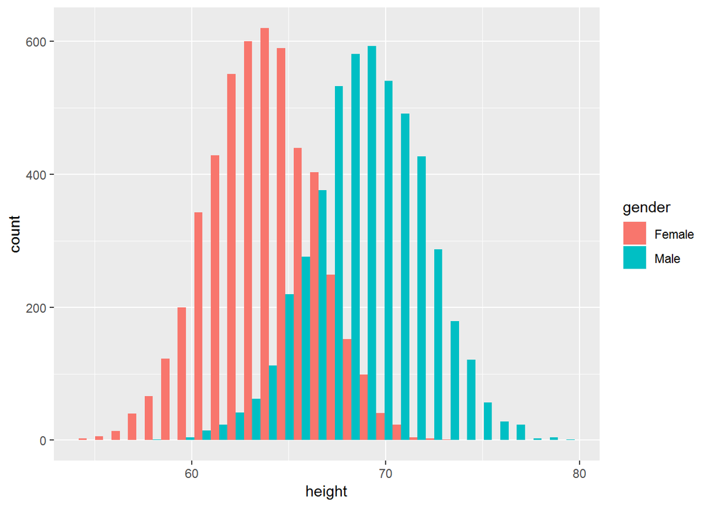

```r
tidy_height %>%
  ggplot(aes(x = height, group = gender, fill = gender)) +
  geom_histogram(position = "dodge")
```

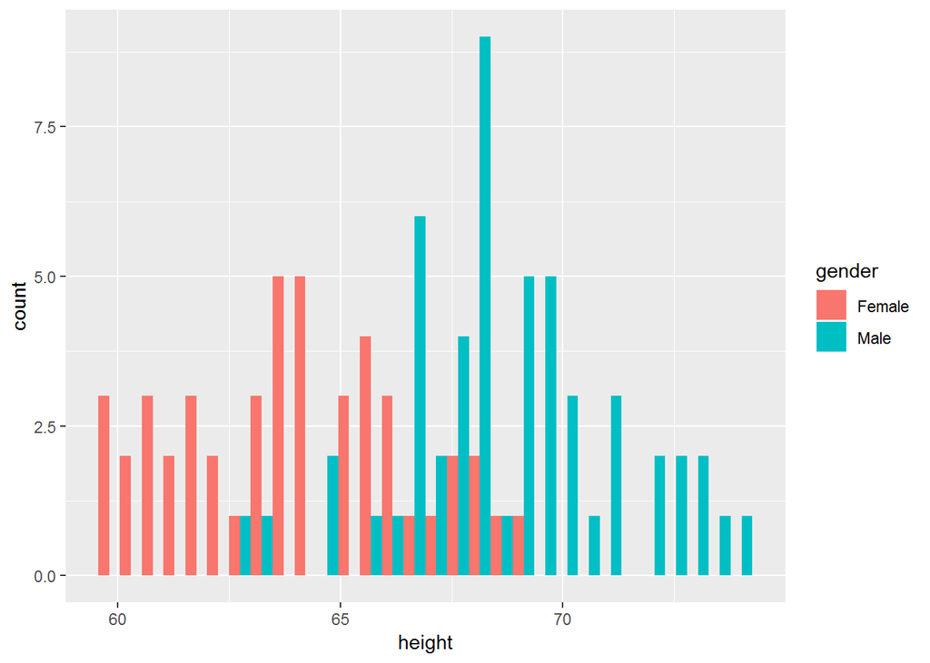

```r
small_tidy_height %>%
  ggplot(aes(x = height, group = gender, fill = gender)) +
  geom_histogram(position = "dodge")
```

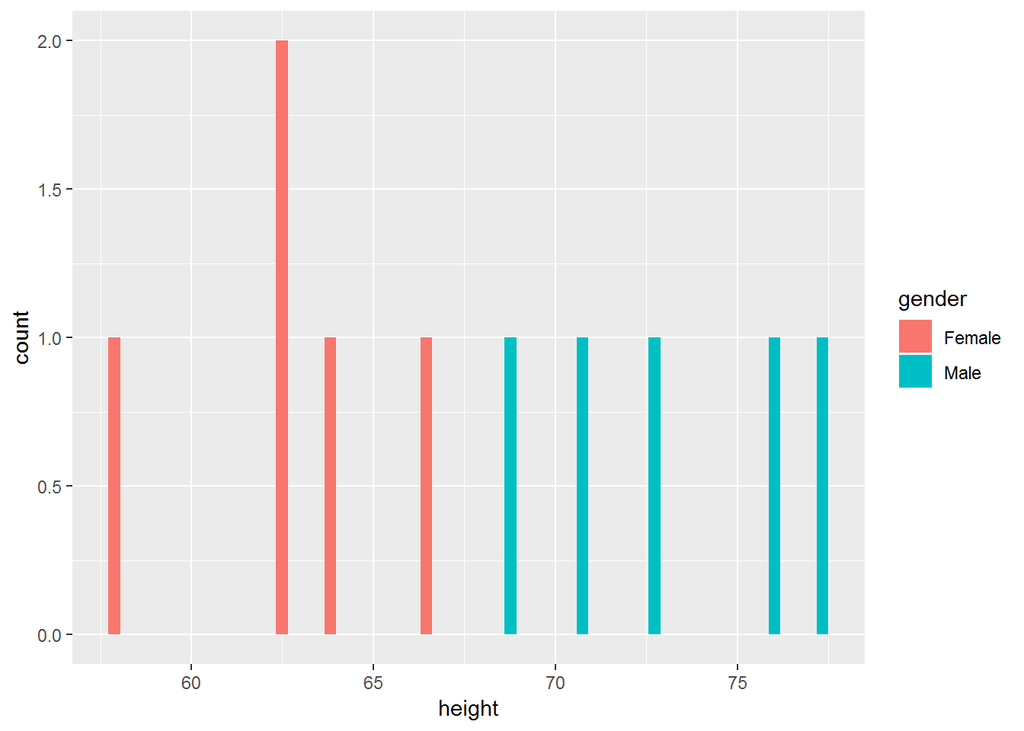

```r
tiny_tidy_height %>%
  ggplot(aes(x = height, group = gender, fill = gender)) +
  geom_histogram(position = "dodge")
```

## Hypothesis test

```r
tiny_obs_mean_diff <-
  tiny_tidy_height %>%
    group_by(gender) %>%
    summarise(mean_height = mean(height)) %>%
    summarise(mean_diff = mean_height[gender == "Male"] - mean_height[gender == "Female"]) %>%
    pull(mean_diff)

tiny_obs_mean_diff
```

```
## [1] 10.0878
```

```r
small_obs_mean_diff <-
  small_tidy_height %>%
    group_by(gender) %>%
    summarise(mean_height = mean(height)) %>%
    summarise(mean_diff = mean_height[gender == "Male"] - mean_height[gender == "Female"]) %>%
    pull(mean_diff)

small_obs_mean_diff
```

```
## [1] 4.811259
```

```r
obs_mean_diff <-
  tidy_height %>%
    group_by(gender) %>%
    summarise(mean_height = mean(height)) %>%
    summarise(mean_diff = mean_height[gender == "Male"] - mean_height[gender == "Female"]) %>%
    pull(mean_diff)

obs_mean_diff
```

```
## [1] 5.317572
```

Null distribution with only 10 observations

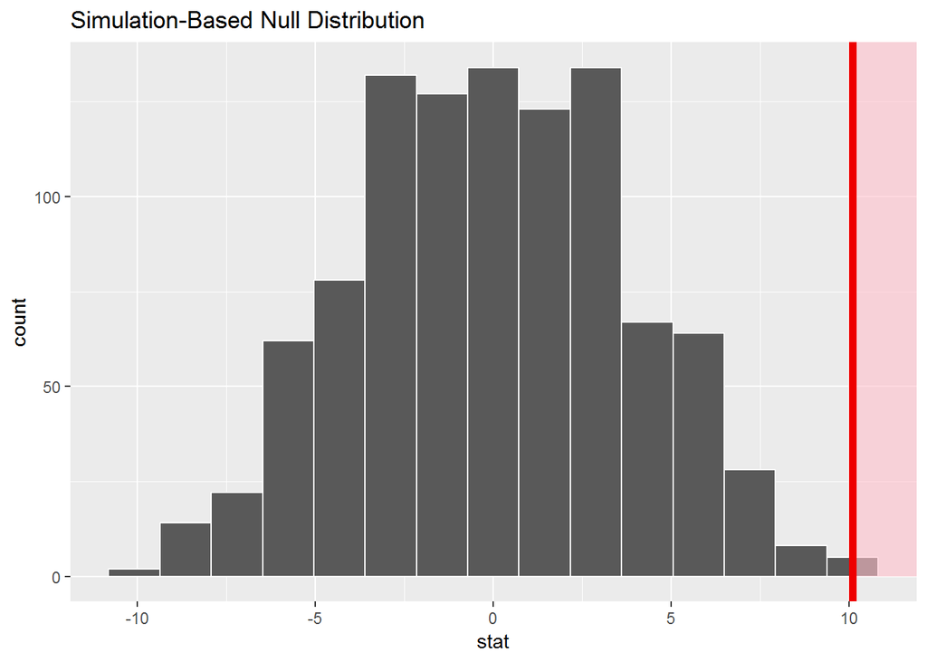

```r
tiny_tidy_height %>%
  specify(height ~ gender) %>%
  hypothesize(null = "independence") %>%
  generate(reps = 1000, type = "permute") %>%
  calculate(stat = "diff in means", order = c("Male", "Female")) %>%
  visualize() +
  shade_p_value(
    obs_stat = tiny_obs_mean_diff,
    direction = "greater"
  )
```

Null distribution with 100 observations

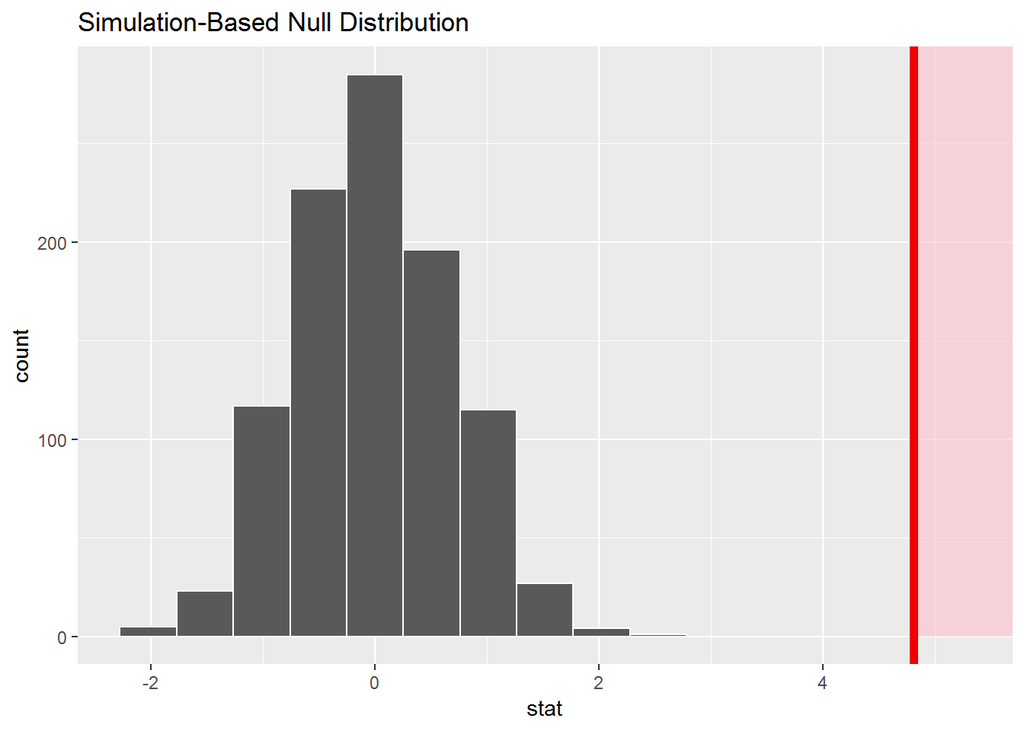

```r
small_tidy_height %>%
  specify(height ~ gender) %>%
  hypothesize(null = "independence") %>%
  generate(reps = 1000, type = "permute") %>%
  calculate(stat = "diff in means", order = c("Male", "Female")) %>%
  visualize() +
  shade_p_value(
    obs_stat = small_obs_mean_diff,
    direction = "greater"
  )
```

Null distribution with all 10 000 observations

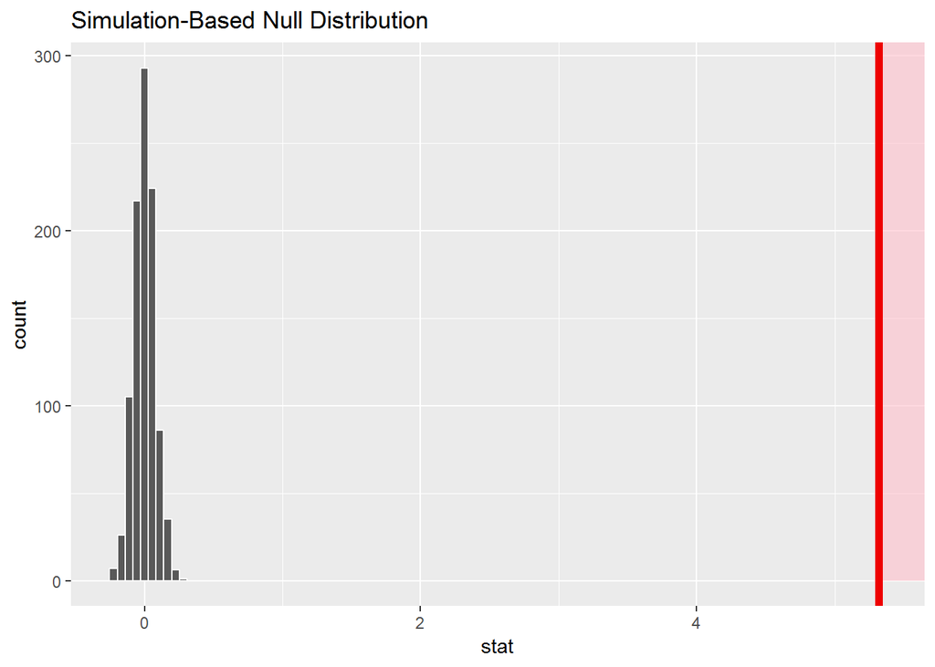

```r
tidy_height %>%
  specify(height ~ gender) %>%
  hypothesize(null = "independence") %>%
  generate(reps = 1000, type = "permute") %>%
  calculate(stat = "diff in means", order = c("Male", "Female")) %>%
  visualize(bins = 100) +
  shade_p_value(
    obs_stat = obs_mean_diff,
    direction = "greater"
  )
```

The range of Null differences is far outside the observed difference, and so the probability there’s no true difference given this dataset is effectively zero.

# Bayes Factors

- Analogy: Courts and Burden of Proof
  - Criminal Courts: ‘Beyond Reasonable Doubt’ (Neyman-Pearson/Classical approach)
  - Civil Courts: ‘Balance of Probabilities’ (The Bayes Factor: Likelihood Ratio)
- Likelihood and Probability
  - > The likelihood of the model given the data is proportional to the probability of the data given the model
  - Likelihood is always relative rather than absolute
    - A model is never *likely*, just *more/less likely* than another model
- Bayes Factors
  - $B(H_A, H_0) = \frac{p(D | H_A)}{p(D | H_0)}$
  - B > 1 : More support for Alternative Hypothesis
  - B < 1 : More support for Null Hypothesis
  - How much more support?
    - < 3: ‘anecdotal’
    - < 10: ‘moderate’
    - < 30: ‘strong’
    - etc

## Example using mtcars dataset

> Given some value of MPG, what’s the relative likelihood the car is manual (Alt) or automatic (Null) transmission?

```r
summaries <-
  mtcars %>%
    group_by(am) %>%
    summarise(
      mean_mpg = mean(mpg),
      sd_mpg   = sd(mpg)
    )

mu_manual    <- summaries %>% filter(am == 1) %>% pull(mean_mpg)
sd_manual    <- summaries %>% filter(am == 1) %>% pull(sd_mpg  )
mu_automatic <- summaries %>% filter(am == 0) %>% pull(mean_mpg)
sd_automatic <- summaries %>% filter(am == 0) %>% pull(sd_mpg  )
```

Bayes factor (Manual cf automatic) given MPG

```r
calc_bayes_factor <- function(value, mu_null, sd_null, mu_alt, sd_alt){
  dnorm(value, mean = mu_alt, sd = sd_alt) / dnorm(value, mean = mu_null, sd = sd_alt)
}
```

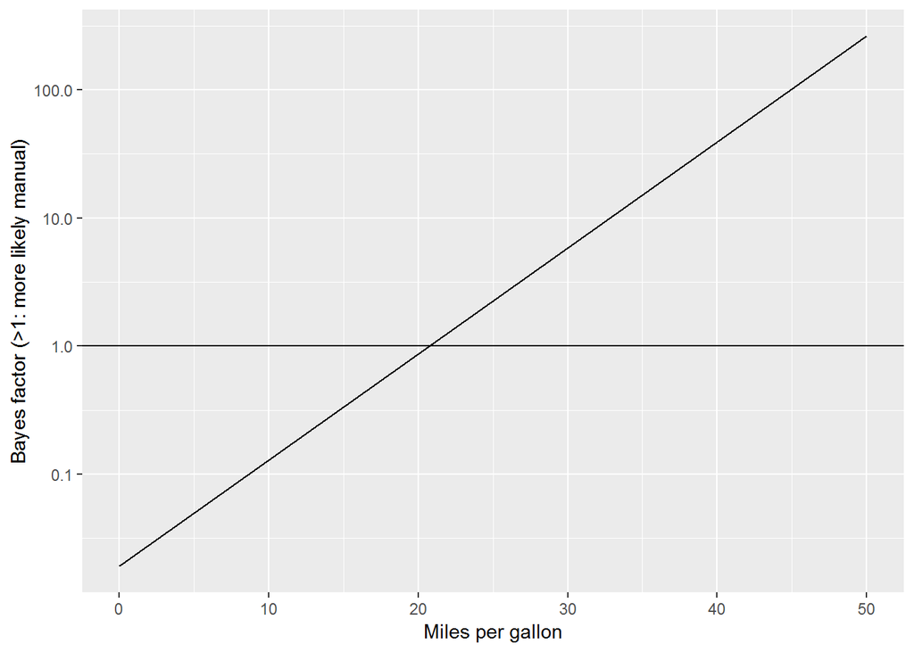

```r
bf_schedule <-
  tibble(
    mpg_vals = seq(0, 50, by = 0.01)
  )  %>%
    mutate(bf = map_dbl(mpg_vals, calc_bayes_factor, mu_null = mu_automatic, sd_null = sd_automatic, mu_alt = mu_manual, sd_alt = sd_manual )
    )

bf_schedule %>%
  ggplot(aes(x = mpg_vals, y = bf)) +
  geom_line() +
  scale_y_log10() +
  geom_hline(yintercept = 1) +
  labs(x = "Miles per gallon",
       y = "Bayes factor (>1: more likely manual)"
  )
```

## Example using our heights data

Get summaries of male and female means and standard deviations

```r
tiny_summaries <-
  tiny_tidy_height %>%
      group_by(gender) %>%
      summarise(
        mean_height = mean(height),
        sd_height = sd(height)
      )

mu_male_tiny      <- tiny_summaries %>% filter(gender == "Male") %>% pull(mean_height)
sd_male_tiny      <- tiny_summaries %>% filter(gender == "Male") %>% pull(sd_height  )
mu_female_tiny    <- tiny_summaries %>% filter(gender == "Female") %>% pull(mean_height)
sd_female_tiny    <- tiny_summaries %>% filter(gender == "Female") %>% pull(sd_height  )

small_summaries <-
  small_tidy_height %>%
      group_by(gender) %>%
      summarise(
        mean_height = mean(height),
        sd_height = sd(height)
      )

mu_male_small      <- small_summaries %>% filter(gender == "Male") %>% pull(mean_height   )
sd_male_small      <- small_summaries %>% filter(gender == "Male") %>% pull(sd_height     )
mu_female_small    <- small_summaries %>% filter(gender == "Female") %>% pull(mean_height )
sd_female_small    <- small_summaries %>% filter(gender == "Female") %>% pull(sd_height   )

summaries <-
  tidy_height %>%
      group_by(gender) %>%
      summarise(
        mean_height = mean(height),
        sd_height = sd(height)
      )

mu_male      <- summaries %>% filter(gender == "Male") %>% pull(mean_height)
sd_male      <- summaries %>% filter(gender == "Male") %>% pull(sd_height  )
mu_female    <- summaries %>% filter(gender == "Female") %>% pull(mean_height)
sd_female    <- summaries %>% filter(gender == "Female") %>% pull(sd_height  )
```

Calculate Bayes Factor Schedules

```r
tiny_bf_schedule <-
  tibble(
    height_vals = seq(50, 90, by = 1)
  )  %>%
    mutate(bf = map_dbl(height_vals, calc_bayes_factor, mu_null = mu_female_tiny, sd_null = sd_female_tiny, mu_alt = mu_male_tiny, sd_alt = sd_male_tiny)
    )

small_bf_schedule <-
  tibble(
    height_vals = seq(50, 90, by = 1)
  )  %>%
    mutate(bf = map_dbl(height_vals, calc_bayes_factor, mu_null = mu_female_small, sd_null = sd_female_small, mu_alt = mu_male_small, sd_alt = sd_male_small)
    )


bf_schedule <-
  tibble(
    height_vals = seq(50, 90, by = 1)
  )  %>%
    mutate(bf = map_dbl(height_vals, calc_bayes_factor, mu_null = mu_female, sd_null = sd_female, mu_alt = mu_male, sd_alt = sd_male)
    )
```

The schedule based on only 10 observations

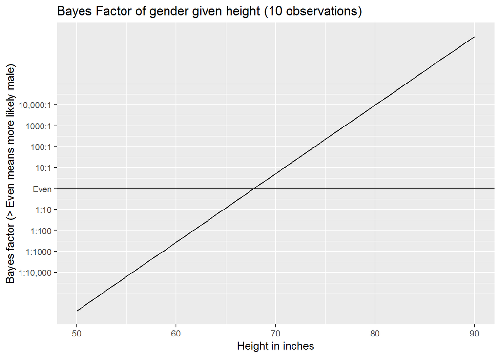

```r
brks <- c(0.0001, 0.001, 0.01, 0.1, 1, 10, 100, 1000, 10000)

lbs <- c("1:10,000", "1:1000", "1:100", "1:10", "Even", "10:1", "100:1", "1000:1", "10,000:1")

tiny_bf_schedule %>%
  ggplot(aes(x = height_vals, y = bf)) +
  geom_line() +
  scale_y_log10(breaks = brks, labels = lbs) +
  geom_hline(yintercept = 1) +
  labs(x = "Height in inches",
       y = "Bayes factor (> Even means more likely male)",
       title = "Bayes Factor of gender given height (10 observations)")
```

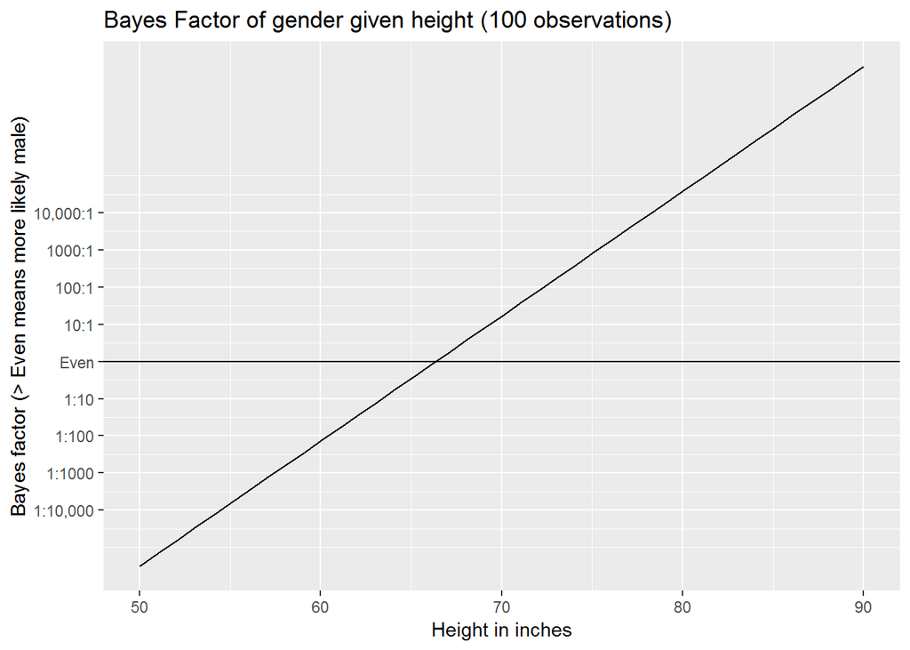

```r
small_bf_schedule %>%
  ggplot(aes(x = height_vals, y = bf)) +
  geom_line() +
  scale_y_log10(breaks = brks, labels = lbs) +
  geom_hline(yintercept = 1) +
  labs(x = "Height in inches",
       y = "Bayes factor (> Even means more likely male)",
       title = "Bayes Factor of gender given height (100 observations)")
```

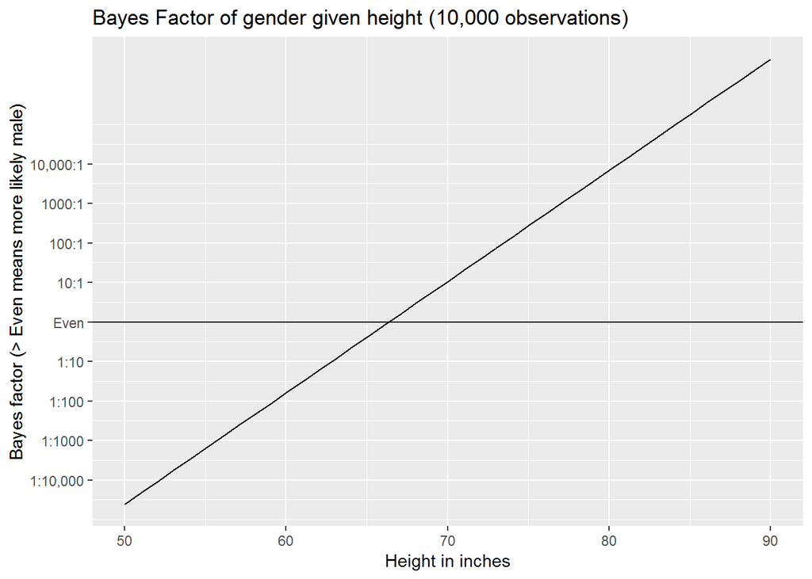

```r
bf_schedule %>%
  ggplot(aes(x = height_vals, y = bf)) +
  geom_line() +
  scale_y_log10(breaks = brks, labels = lbs) +
  geom_hline(yintercept = 1) +
  labs(x = "Height in inches",
       y = "Bayes factor (> Even means more likely male)",
       title = "Bayes Factor of gender given height (10,000 observations)")
```

Finally, what’s the relative likelihood that I’m male?

```r
(my_height <- 1.7145 * 39.3701) # to get to height in inches
```

```
## [1] 67.50004
```

```r
calc_bayes_factor(value = my_height, mu_null = mu_female_tiny, sd_null = sd_female_tiny, mu_alt = mu_male_tiny, sd_alt = sd_male_tiny)
```

```
## [1] 0.7854343
```

```r
calc_bayes_factor(value = my_height, mu_null = mu_female_small, sd_null = sd_female_small, mu_alt = mu_male_small, sd_alt = sd_male_small)
```

```
## [1] 2.403596
```

```r
calc_bayes_factor(value = my_height, mu_null = mu_female, sd_null = sd_female, mu_alt = mu_male, sd_alt = sd_male)
```

```
## [1] 2.084433
```

So, from height alone, it’s about 28% more likely I’m *female* if using the tiny dataset, about two and a half times more likely I’m male if using the small dataset, and about twice as likely I’m male if using the full dataset.

# Conclusion/Discussion

- There-is-only-one-test makes it easy to think through hypothesis testing
- The `infer` package makes it straightforward to apply this approach
- Computationally intensive and analytic approaches do the same thing in different ways
- Classical (Neyman-Pearson style) hypothesis tests may not answer the question you want to ask
- Bayes Factors are an alterantive and often more pragmatic way of weighing the evidence